# Gas budget dashboard

Should I amp up, hold steady, or dial down this week?

Author

Márton Kiss, MD

Published

August 17, 2026

```
This week&rsquo;s recommendation
```

```
DIAL DOWN
```

In a harsh scenario you’d overshoot by ~312 m3. Cut back or use the heat pump.

## The burn-down chart

This is the heart of the report. It answers one question: **will the year’s subsidised gas allowance (1 729 m³) last until December 31?**

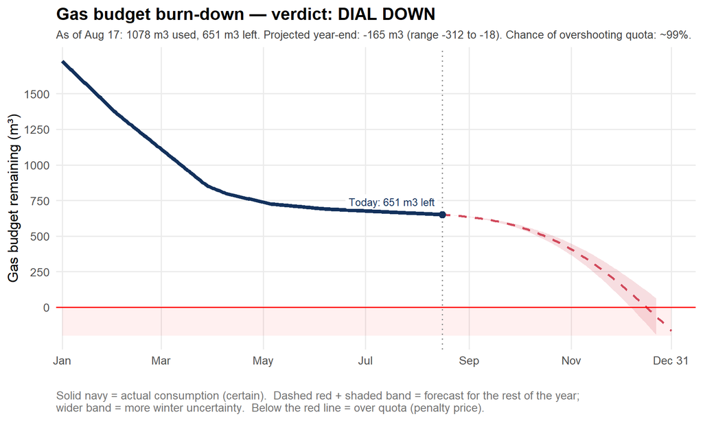

**TipHow to read this chart**

- **Solid navy line** — gas budget actually remaining, reconstructed from your meter readings. This part is *certain*: it already happened.
- **Dashed red line** — the *expected* trajectory for the rest of the year, based on 30 years of weather and your current consumption efficiency.
- **Shaded pink band** — the 95 % range of outcomes. It is narrow now and **fans out toward winter**, because the single biggest unknown is *how cold the coming heating season will be*. A mild autumn keeps you near the top of the band; a harsh one pushes you toward the bottom.
- **Red horizontal line (0 m³)** — the quota boundary. Anything below it is gas billed at the **penalty price** (~7.5× the subsidised rate).

## Where the budget stands today

| Metric | Value |
| --- | --- |
| Tracking window | Jan 1 – Dec 31, 2026 |
| Days elapsed | 228 of 364 |
| Gas consumed since Jan 1 | 1 078 m³ |
| Gas remaining in quota | 651 m³ |
| Expected need for rest of year (95% CI) | 669 m³ – 963 m³ |
| Projected year-end balance (95% CI) | -165 m³ (-312 m³ to -18 m³) |
| Chance of overshooting the quota | ~99% |
| Current daily rate (latest meter interval) | 0.56 m³/day |
| Daily rate to stay on budget | 4.93 – 7.10 m³/day |

**Note**

Recent 3-day average outdoor temperature is **25.1 °C** (above 10 °C). The heat pump is the cheaper way to add heat right now — save the discounted gas for the cold months.

# Supporting detail

The verdict above is driven by two ideas: (1) how much *heating need* is still ahead of us, and (2) how much *gas* we burn per unit of heating need. The next two charts show each.

## Efficiency: gas burned per unit of heating need

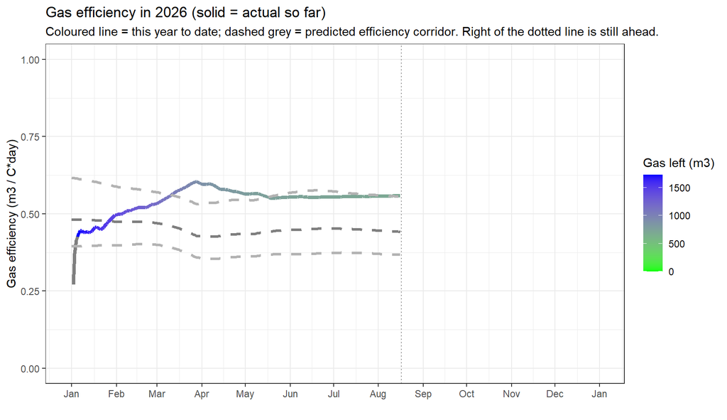

Figure 1

## How predictable is the rest of the year?

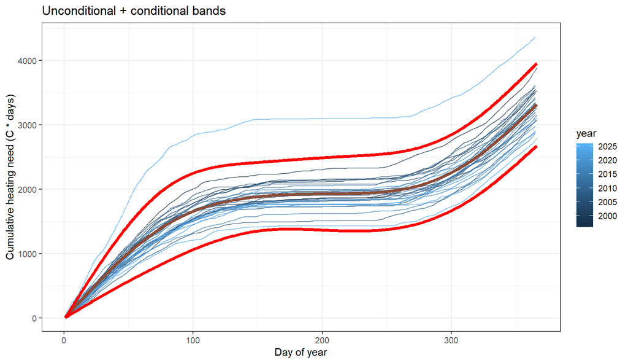

Figure 2

# Methodology

**NoteModelling notes (click to expand)**

**Heating need.** Assuming a constant indoor target of 20 °C and heat loss proportional to the indoor–outdoor temperature gap, we sum the “missing degrees” below 20 °C each day to get a **cumulative heating need** in °C·days.

**Weather model.** A GLS model with a natural spline (8 df) captures the seasonal mean of cumulative heating need across ~30 years of Budapest weather (station 12843). An exponential variance structure lets the spread grow through the year.

**Conditional forecast.** Given the heating need observed *so far this year*, the end-of-year total is forecast with a conditional-normal model: the correlation between today’s running total and each future day (estimated empirically across years) shrinks the uncertainty band the further into the season we are.

**Gas from heat.** Gas use is split into two parts: a per-day **hot-water baseline** (present even when no heating is needed) and **heating gas** proportional to the cumulative heating need. The baseline is estimated from this year’s data as the marginal gas-per-day controlling for heat need; when that estimate is unreliable (collinear within a single winter, so it can even go negative) it falls back to a dedicated 0.4 m³/day. The same baseline and heating efficiency feed both the burn-down and the efficiency chart.

**Budget window.** Tracking runs on the **calendar year (Jan 1 – Dec 31)**, anchored to the meter value interpolated at Jan 1. (The official subsidised-quota year is Aug–Jul, but the practical átalány true-up happens in early January, so the calendar year is the relevant window here.)

**Pipeline.** `iter1` (data prep) → `iter2` (consumption curves) → `iter3` (cumulative heat model) → `iter4` (conditional prediction) → `iter5` (decision tool). Re-run after each new meter reading.

*Compiled 2026-08-17 09:00:47.272853.*